# Multispecies Recruitment

Sarah Gaichas

31 October, 2024

```r
# hacks for data not yet in stockSmart as of January 2024
# mackerel MT output from draft via Dan Hennen and Kiersten Curti
# see local folder mackerelMT2023 for inputs
# set addmack to FALSE when stockSmart is updated

addmack <- TRUE

# add mackerel MT results by hand
if(addmack){
  mackSS <- stocksmart::stockAssessmentData |>
    dplyr::filter(StockName %in% c("Atlantic mackerel - Gulf of Maine / Cape Hatteras")) |>
    dplyr::filter(AssessmentYear == max(AssessmentYear)) |>
    dplyr::select(StockName, Metric, Description, Units, AssessmentYear, Jurisdiction) |>
    dplyr::group_by(Metric) |>
    dplyr::distinct()

  # 2013-2022 match for values in stocksmart to add units, etc from there
  newmack <- read.csv(here::here("mackerelMT2023/model_results.csv")) |>
    dplyr::select(Year, Abundance = SSB, Recruitment = Rect) |>
    tidyr::pivot_longer(-Year, names_to = "Metric", values_to = "Value") |>
    dplyr::mutate(StockName = "Atlantic mackerel - Gulf of Maine / Cape Hatteras") |>
    dplyr::left_join(mackSS)

}
```

## Evaluate change in recruitment over time for assessed species

This is an update to analyses presented in Perretti et al. (2017). Code courtesy Charles Perretti and Kim Bastille.

### Get stocksmart info

UPDATE: StockSMART was updated in mid-December 2023 with Northeast US assessment results, and `stocksmart` now has all results. *Except!* Atlantic mackerel had only 2013-2022 in stockSMART so I am adding the draft results from the MT assessment by Kiersten Curti via Dan Hennen.

Can we pull most recent recruitment and SSB or other B outputs from Northeast US stock assessments? Which species do we have? What units are recruitments in?

These are all stocks, most recent assessment year reporting recruitment.

```r
NErec <- stocksmart::stockAssessmentData %>%
  filter(RegionalEcosystem == "Northeast Shelf",
         Metric == "Recruitment") %>%
  group_by(StockName) %>%
  filter(AssessmentYear == max(AssessmentYear)) %>%
  ungroup()

if(addmack) {
  macrec <- newmack |>
    dplyr::filter(Metric == "Recruitment")

  NErec <- full_join(NErec, macrec)
}

sppunits <- NErec %>%
  select(StockName, StockArea, Description, Units) %>%
  distinct()

datatable(sppunits, rownames = FALSE,
             options = list(scrollX = TRUE,
                            pageLength = 10))
```

| StockName | StockArea | Description | Units |
| --- | --- | --- | --- |
| Acadian redfish - Gulf of Maine / Georges Bank | Gulf of Maine / Georges Bank | Abundance - Age 1 (Mean) | Thousand Recruits |
| American plaice - Gulf of Maine / Georges Bank | Gulf of Maine / Georges Bank | Recruits - Age 1 | Thousand Recruits |
| Atlantic cod - Eastern Georges Bank | Eastern Georges Bank | Abundance, Age 1 (Mean) | Number x 1,000 |
| Atlantic cod - Georges Bank | Georges Bank | Abundance - Age 1 | Thousand Recruits |
| Atlantic cod - Gulf of Maine | Gulf of Maine | Abundance, Age 1 (Mean) | Number x 1,000 |
| Atlantic herring - Northwestern Atlantic Coast | Northwestern Atlantic Coast | Number of Fish - Age 1 | Thousand Recruits |
| Atlantic mackerel - Gulf of Maine / Cape Hatteras | Gulf of Maine / Cape Hatteras | Abundance - Age 1 | Thousand Recruits |
| Atlantic surfclam - Mid-Atlantic Coast | Mid-Atlantic Coast | Recruitment / Unifished Recruitment | Ratio |
| Atlantic wolffish - Gulf of Maine / Georges Bank | Gulf of Maine / Georges Bank | Recruits - Age 1 | Million Recruits |
| Black sea bass - Mid-Atlantic Coast | Mid-Atlantic Coast | Recruits - Age 1 | Million Recruits |

[output cut: 26 more lines]

```r
NEbio <- stocksmart::stockAssessmentData %>%
  filter(RegionalEcosystem == "Northeast Shelf",
         Metric == "Abundance") %>%
  group_by(StockName) %>%
  filter(AssessmentYear == max(AssessmentYear)) %>%
  ungroup()

if(addmack) {
  macbio <- newmack |>
    dplyr::filter(Metric == "Abundance")

  NEbio <- full_join(NEbio, macbio)
}

sppunits <- NEbio %>%
  select(StockName, StockArea, Description, Units) %>%
  distinct()

datatable(sppunits, rownames = FALSE,
             options = list(scrollX = TRUE,
                            pageLength = 10))
```

| StockName | StockArea | Description | Units |
| --- | --- | --- | --- |
| Acadian redfish - Gulf of Maine / Georges Bank | Gulf of Maine / Georges Bank | Spawning Stock Biomass | Metric Tons |
| American plaice - Gulf of Maine / Georges Bank | Gulf of Maine / Georges Bank | Spawning Stock Biomass | Metric Tons |
| Atlantic cod - Eastern Georges Bank | Eastern Georges Bank | Summary Biomass, Age 3+ (Mean; Retro Adjusted Terminal Year) | Metric Tons |
| Atlantic cod - Georges Bank | Georges Bank | Survey-Estimated Biomass - Smoothed | kg / tow |
| Atlantic cod - Gulf of Maine | Gulf of Maine | Mature Biomass (Mean) | Metric Tons |
| Atlantic halibut - Northwestern Atlantic Coast | Northwestern Atlantic Coast | Catch Multiplier | Rate |
| Atlantic herring - Northwestern Atlantic Coast | Northwestern Atlantic Coast | Spawning Stock Biomass - Retrospective Adjusted | Metric Tons |
| Atlantic mackerel - Gulf of Maine / Cape Hatteras | Gulf of Maine / Cape Hatteras | Spawning Stock Biomass | Metric Tons |
| Atlantic salmon - Gulf of Maine | Gulf of Maine | Count of Total Returns | Adult Fish |
| Atlantic surfclam - Mid-Atlantic Coast | Mid-Atlantic Coast | Spawning Stock Biomass / Blim | Ratio |

[output cut: 41 more lines]

Select down to stocks used in SOE productivity anomaly indicator? Won’t split them by EPU but could map some stocks to different regions kinda. Or just pick MA managed stocks in stocksmart? Here just trying to get a list of stocks that have both recruitment and biomass in stocksmart. Weeding out recruitment measures that are not in numbers for now.

Also, lets not use assessments prior to 2019.

ADD A CHECK: do we only have one assessment per species? Yes, we did pull max(AssessmentYear)

Which assessments are in `stocksmart` with assessment 2019 or later? Spawning stock biomass on the left and recruitment on the right:

|  | StockName | AssessmentYear |
| --- | --- | --- |
| 1 | Acadian redfish - Gulf of Maine / Georges Bank | 2023 |
| 2 | American plaice - Gulf of Maine / Georges Bank | 2022 |
| 3 | Atlantic cod - Georges Bank | 2021 |
| 4 | Atlantic halibut - Northwestern Atlantic Coast | 2022 |
| 5 | Atlantic herring - Northwestern Atlantic Coast | 2022 |
| 6 | Atlantic mackerel - Gulf of Maine / Cape Hatteras | 2023 |
| 7 | Atlantic salmon - Gulf of Maine | 2022 |
| 8 | Atlantic surfclam - Mid-Atlantic Coast | 2020 |
| 9 | Atlantic wolffish - Gulf of Maine / Georges Bank | 2022 |
| 10 | Barndoor skate - Georges Bank / Southern New England | 2023 |

[output cut: 37 more lines]

|  | StockName | AssessmentYear |
| --- | --- | --- |
| 1 | Acadian redfish - Gulf of Maine / Georges Bank | 2023 |
| 2 | American plaice - Gulf of Maine / Georges Bank | 2022 |
| 3 | Atlantic herring - Northwestern Atlantic Coast | 2022 |
| 4 | Atlantic mackerel - Gulf of Maine / Cape Hatteras | 2023 |
| 5 | Atlantic surfclam - Mid-Atlantic Coast | 2020 |
| 6 | Atlantic wolffish - Gulf of Maine / Georges Bank | 2022 |
| 7 | Black sea bass - Mid-Atlantic Coast | 2021 |
| 8 | Bluefish - Atlantic Coast | 2023 |
| 9 | Butterfish - Gulf of Maine / Cape Hatteras | 2022 |
| 10 | Haddock - Eastern Georges Bank | 2023 |

[output cut: 13 more lines]

### The input assessment set

Which stocks with assessments 2019 or newer have both recruitment in numbers and SSB in biomass? This limits us to fewer stocks.

```r
# first pass only stocks with both rec in N and bio but keep all years of bio

NErecN <- NErec %>%
  filter(AssessmentYear>2018,
         Units %in% c("Thousand Recruits",
                      "Number x 1,000,000",
                      "Number x 1,000",
                      "Million Recruits"))

NErecstocks <- NErecN %>%
  select(StockName) %>%
  distinct()

NEbiohasrec <- NEbio %>%
  filter(StockName %in% NErecstocks$StockName)

bothyr <- NEbiohasrec %>%
  group_by(StockName) %>%
  select(StockName, AssessmentYear) %>%
  distinct()

datatable(bothyr)
```

|  | StockName | AssessmentYear |
| --- | --- | --- |
| 1 | Acadian redfish - Gulf of Maine / Georges Bank | 2023 |
| 2 | American plaice - Gulf of Maine / Georges Bank | 2022 |
| 3 | Atlantic herring - Northwestern Atlantic Coast | 2022 |
| 4 | Atlantic mackerel - Gulf of Maine / Cape Hatteras | 2023 |
| 5 | Atlantic wolffish - Gulf of Maine / Georges Bank | 2022 |
| 6 | Black sea bass - Mid-Atlantic Coast | 2021 |
| 7 | Butterfish - Gulf of Maine / Cape Hatteras | 2022 |
| 8 | Haddock - Eastern Georges Bank | 2023 |
| 9 | Haddock - Georges Bank | 2022 |
| 10 | Haddock - Gulf of Maine | 2022 |

[output cut: 10 more lines]

### Standardize assessment outputs

Next steps:

Reconcile the units so inputs are the same across stocks

Units of recruitment in numbers of fish at age 1 is the input to the survey based productivity anomaly indicator. We’ll need to convert all to numbers and note the age of recruitment for each stock to shift recruitment appropriately.

```r
NErecNstd <- NErecN %>%
  mutate(NfishRec = case_when(Units == "Thousand Recruits" ~ Value*1000,
                              Units == "Number x 1,000,000" ~ Value*1000000,
                              Units == "Number x 1,000" ~ Value*1000,
                              Units == "Million Recruits" ~ Value*1000000,
                              TRUE ~ as.numeric(NA)),
         AgeRec = as.numeric(stringr::str_extract(Description, "(\\d)+")),
         SSByr = Year-AgeRec
         )
```

Plot each Rec series by SSByr

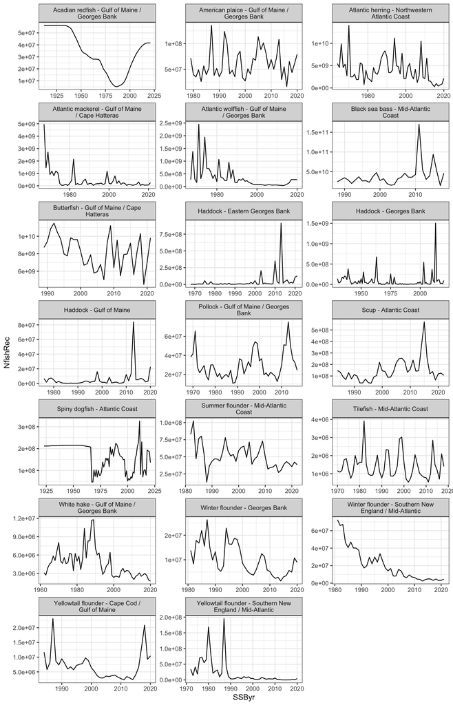

```r
ggplot(NErecNstd, aes(x=SSByr, y=NfishRec)) +
  geom_line() +
  theme_bw() +
  facet_wrap(~StockName, ncol = 3, scales = "free",
             labeller = labeller(StockName = label_wrap_gen(35)))
```

Units of biomass (all listed as mature/spawning stock or retro adjusted spawning stock) are converted to kg for similarity with survey anomaly code.

```r
NEbioBstd <- NEbiohasrec %>%
  mutate(SSBkg = case_when(Units == "Thousand Metric Tons" ~ Value*1000000,
                           Units == "Metric Tons" ~ Value*1000,
                           Units == "Million Pups" ~ Value*10000000/2,
                           TRUE ~ as.numeric(NA))
         #AgeRec = as.numeric(stringr::str_extract(Description, "(\\d)+")),
         #SSByr = Year-AgeRec
         )
```

Plot each SSB series by Year

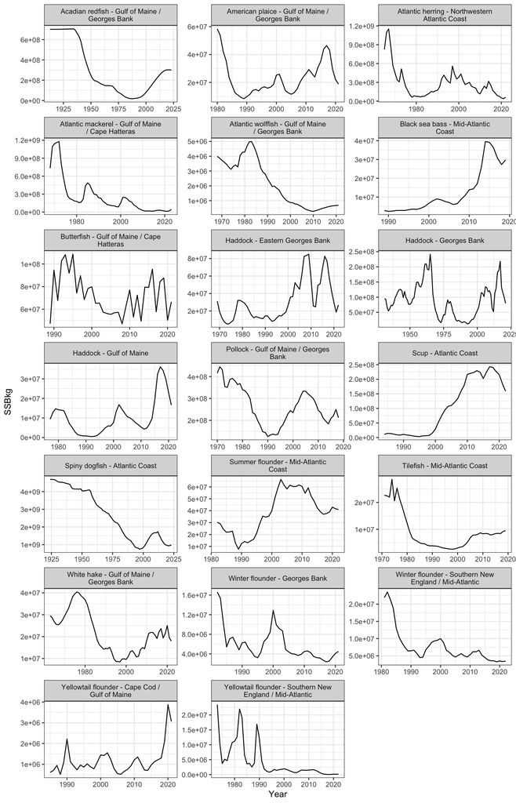

```r
ggplot(NEbioBstd, aes(x=Year, y=SSBkg)) +
  geom_line() +
  theme_bw() +
  facet_wrap(~StockName, ncol = 3, scales = "free",
             labeller = labeller(StockName = label_wrap_gen(35)))
```